# Taipei_2019_July

## Data Description

### Context

Since 2008, Airbnb has been a platform for travelers having another option of staying in local hosts’ home different from hotel and resort

### Content

The original source is from the database of Airbnb’s websit opened to the public. The csv file includes all needed information to find out more about hosts, geographical availability, necessary metrics

### Data Visualization

Using plots and excel to produce charts  
1.Get correlation between different variables  
2.The rental accommodation density for areas (bar chart,distribution map, heat map)  
3.Price and areas(Price Density and Distribution, Price distribution on map)  
4.Room type and minimum nights  
5.Customer Churn  
6.Accommodation on rent

```python
import pandas as pd
df=pd.read_csv("listingsRoc.csv")
df.head(5)
```

|  | id | name | host_id | host_name | neighbourhood_group | neighbourhood | latitude | longitude | room_type | price | minimum_nights | number_of_reviews | last_review | reviews_per_month | calculated_host_listings_count | availability_365 |
| --- | --- | --- | --- | --- | --- | --- | --- | --- | --- | --- | --- | --- | --- | --- | --- | --- |
| 0 | 68396 | Zhongxiao Dunhua Studio C near MRT | 339014 | Lisa | NaN | 大安區 | 25.04258 | 121.55365 | Entire home/apt | 1555 | 7 | 2 | 2018-06-20 | 0.03 | 12 | 305 |
| 1 | 68398 | Tonghua Vacation Studio C | 339014 | Lisa | NaN | 大安區 | 25.02925 | 121.55561 | Entire home/apt | 933 | 30 | 7 | 2019-04-01 | 0.09 | 12 | 317 |
| 2 | 74641 | 黑白雙人房@南京復興站｡小巨蛋斜對面｡溫泉式浴缸｡ | 393116 | Yi-Wan | NaN | 松山區 | 25.05159 | 121.54747 | Private room | 1555 | 3 | 48 | 2019-05-05 | 0.51 | 4 | 63 |
| 3 | 74643 | 小巨蛋｡南京復興站溫馨套房 | 393116 | Yi-Wan | NaN | 松山區 | 25.05067 | 121.54568 | Private room | 1306 | 2 | 51 | 2019-06-09 | 0.50 | 4 | 70 |
| 4 | 178036 | 單人床位 Single bunk bed [mixed dorm for 4pax] | 851825 | TaipeiTaipei Hostel | NaN | 中正區 | 25.04488 | 121.51305 | Shared room | 404 | 1 | 60 | 2019-07-24 | 0.62 | 9 | 343 |

### The Column descriptions

neighbourhood_group:location  
neighbourhood:area  
room_type:listing space type  
minimum_nights:amount of nights minimum  
number_of_reviews:number of reviews  
last_review:latest review  
reviews_per_month:number of reviews per month  
calculated_host_listings_count:amount of listing per host  
availability_365:number of days when listing is available for booking

### The datatypes of the dataset and the total row number

```python
df.dtypes,len(df)
```

```
(id                                  int64
 name                               object
 host_id                             int64
 host_name                          object
 neighbourhood_group               float64
 neighbourhood                      object
 latitude                          float64
 longitude                         float64
 room_type                          object
 price                               int64
 minimum_nights                      int64
 number_of_reviews                   int64
 last_review                        object
 reviews_per_month                 float64
 calculated_host_listings_count      int64
 availability_365                    int64
 dtype: object, 9937)
```

## Clean data

1.Check the duplicates: no duplicates  
2.List the NaN values: four columns  
3.Deleting redundant columns: neighbourhood_group is an empty column

```python
df.duplicated().sum()
```

```
0
```

```python
df.isnull().sum()
```

```
id                                   0
name                                 5
host_id                              0
host_name                            3
neighbourhood_group               9937
neighbourhood                        0
latitude                             0
longitude                            0
room_type                            0
price                                0
minimum_nights                       0
number_of_reviews                    0
last_review                       1966
reviews_per_month                 1966
calculated_host_listings_count       0
availability_365                     0
dtype: int64
```

**List the total number of NaN values in each column. The result comes out a few in two columns of name and host_name though. The following analysis will not use those so I save them.**

```python
df.drop(['neighbourhood_group'],axis=1,inplace=True)
```

```python
#df.to_csv('taipei_excelUse.csv',encoding='utf_8_sig',index=False)
```

# The Dataset Overview

In order to see the real situation of running lodgings, rows which the rooms or houses are not open to the public ought to be remove.

```python
df=df[df['last_review'].isnull().values==False]
len(df)
```

```
7971
```

### Get Correlation between different variables

1. Moderate positive relationship(0.5~0.75): host_ID and ID(0.53), number_of_reviews and reviews_per_month(0.62)
2. Weak negative relationship (-0.3~-0.5):ID and number_of_reviews(-0.42)
3. **Due to the variables are non-normal distribution observed from Pandas Profiling Report; the correlation table doesn't do much for our analysis**

```python
df.drop(['neighbourhood'],axis=1).corr().style.background_gradient(cmap='coolwarm')
```

|  | id | host_id | latitude | longitude | price | minimum_nights | number_of_reviews | reviews_per_month | calculated_host_listings_count | availability_365 |
| --- | --- | --- | --- | --- | --- | --- | --- | --- | --- | --- |
| id | 1 | 0.538794 | -0.051458 | -0.0976184 | -0.0314783 | -0.0366152 | -0.422602 | 0.181172 | 0.0295954 | -0.145853 |
| host_id | 0.538794 | 1 | -0.00221648 | -0.0384928 | -0.0159605 | -0.0195663 | -0.221986 | 0.114076 | -0.0441602 | -0.0832159 |
| latitude | -0.051458 | -0.00221648 | 1 | -0.142155 | 0.0218681 | 0.0037905 | 0.00563481 | -0.0258129 | -0.0852001 | 0.0575566 |
| longitude | -0.0976184 | -0.0384928 | -0.142155 | 1 | 0.0241273 | 0.0210558 | 0.00128835 | -0.0856492 | -0.140929 | -0.0529864 |
| price | -0.0314783 | -0.0159605 | 0.0218681 | 0.0241273 | 1 | 0.00603218 | -0.0261184 | -0.0396049 | -0.0216765 | 0.0169615 |
| minimum_nights | -0.0366152 | -0.0195663 | 0.0037905 | 0.0210558 | 0.00603218 | 1 | -0.0353186 | -0.0575473 | 0.0126488 | 9.90699e-05 |
| number_of_reviews | -0.422602 | -0.221986 | 0.00563481 | 0.00128835 | -0.0261184 | -0.0353186 | 1 | 0.62764 | -0.118994 | 0.0115399 |
| reviews_per_month | 0.181172 | 0.114076 | -0.0258129 | -0.0856492 | -0.0396049 | -0.0575473 | 0.62764 | 1 | -0.117706 | -0.0863249 |
| calculated_host_listings_count | 0.0295954 | -0.0441602 | -0.0852001 | -0.140929 | -0.0216765 | 0.0126488 | -0.118994 | -0.117706 | 1 | 0.0169415 |
| availability_365 | -0.145853 | -0.0832159 | 0.0575566 | -0.0529864 | 0.0169615 | 9.90699e-05 | 0.0115399 | -0.0863249 | 0.0169415 | 1 |

```python
df['neighbourhood']=df['neighbourhood'].replace('大安區','Daan大安區')
df['neighbourhood']=df['neighbourhood'].replace('萬華區','Wanhua萬華區')
df['neighbourhood']=df['neighbourhood'].replace('中山區','Zhongshan中山區')
df['neighbourhood']=df['neighbourhood'].replace('中正區','Zhongzheng中正區')
df['neighbourhood']=df['neighbourhood'].replace('信義區','Xinyi信義區')
df['neighbourhood']=df['neighbourhood'].replace('內湖區','Neihu內湖區')
df['neighbourhood']=df['neighbourhood'].replace('北投區','Beitou北投區')
df['neighbourhood']=df['neighbourhood'].replace('南港區','Nangang南港區')
df['neighbourhood']=df['neighbourhood'].replace('士林區','Shilin士林區')
df['neighbourhood']=df['neighbourhood'].replace('大同區','Datong大同區')
df['neighbourhood']=df['neighbourhood'].replace('文山區','Wenshan文山區')
df['neighbourhood']=df['neighbourhood'].replace('松山區','Songshan松山區')
```

## The Rental Accommodation Density for Areas

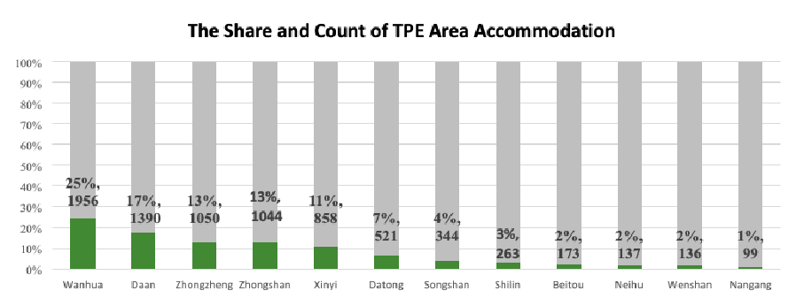

```python
import matplotlib.pyplot as plt #plt 用於顯示圖片
import matplotlib.image as mpimg # 用於讀取圖片
plt.figure(figsize=(16,8))
countArea = mpimg.imread('countArea.png')
plt.imshow(countArea)
plt.axis('off')
plt.show()
```

### ✦ The image presents the contribution of all areas

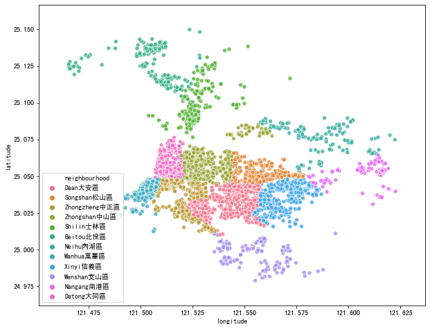

```python
import seaborn as sns
plt.rcParams['font.sans-serif']=['SimHei']
plt.rcParams['axes.unicode_minus']=False
plt.figure(figsize=(10,8))
sns.scatterplot(data=df,x='longitude',y='latitude',hue='neighbourhood',cmap=plt.get_cmap('jet'),alpha=0.8)
plt.ioff()
```

### ✦ Present the density by heat map

The highest Density colored in red and lowest ones in blue

```python
import folium
from folium.plugins import HeatMap
m=folium.Map([df['latitude'].median(), df['longitude'].median()],zoom_start=11.5)
HeatMap(df[['latitude','longitude']].dropna(),radius=8,gradient={0.2:'blue',0.4:'purple',0.6:'orange',1.0:'red'}).add_to(m)
display(m)
```

[interactive chart not shown]

```python
#import pandas_profiling
#df.profile_report()
```

## Price and Areas

### ✦ The statistics

1. The most expensive price lands on Xinyi, following by Songshan and Datong with over 300000
2. The largest price range is also Xinyi, following by Songshan,Datong and Beitou
3. All areas have a similar lowest price between 300 and 400

```python
PriceStat=df['price'].groupby(df['neighbourhood']).describe()
PriceStat['range']=PriceStat['max']-PriceStat['min']
PriceStat['cv']=PriceStat['std']/PriceStat['mean']
PriceStat
#PriceStat.to_csv("PriceStat.csv",encoding='utf_8_sig')
```

| neighbourhood | count | mean | std | min | 25% | 50% | 75% | max | range | cv |
| --- | --- | --- | --- | --- | --- | --- | --- | --- | --- | --- |
| Beitou北投區 | 173.0 | 3328.965318 | 22717.030892 | 311.0 | 746.0 | 1181.0 | 2052.00 | 299913.0 | 299602.0 | 6.824052 |
| Daan大安區 | 1390.0 | 2171.710791 | 2175.833294 | 311.0 | 995.0 | 1555.0 | 2612.00 | 30874.0 | 30563.0 | 1.001898 |
| Datong大同區 | 521.0 | 2600.378119 | 13182.160486 | 342.0 | 995.0 | 1524.0 | 2487.00 | 300006.0 | 299664.0 | 5.069324 |
| Nangang南港區 | 99.0 | 1265.353535 | 921.088135 | 311.0 | 591.0 | 995.0 | 1710.00 | 5565.0 | 5254.0 | 0.727929 |
| Neihu內湖區 | 136.0 | 2627.014706 | 4712.865377 | 311.0 | 902.0 | 1492.0 | 2370.75 | 43529.0 | 43218.0 | 1.794000 |
| Shilin士林區 | 263.0 | 1633.235741 | 2446.707833 | 373.0 | 902.0 | 1213.0 | 1772.00 | 36160.0 | 35787.0 | 1.498074 |
| Songshan松山區 | 344.0 | 2671.773256 | 16189.915743 | 342.0 | 995.0 | 1368.0 | 2176.00 | 300970.0 | 300628.0 | 6.059614 |
| Wanhua萬華區 | 1956.0 | 1938.046524 | 1467.702597 | 311.0 | 1213.0 | 1555.0 | 2208.00 | 24998.0 | 24687.0 | 0.757310 |
| Wenshan文山區 | 137.0 | 1795.364964 | 2208.061759 | 311.0 | 871.0 | 1275.0 | 1897.00 | 19992.0 | 19681.0 | 1.229868 |
| Xinyi信義區 | 858.0 | 3193.505828 | 15126.030084 | 311.0 | 1119.0 | 1803.0 | 2985.00 | 310919.0 | 310608.0 | 4.736497 |
| Zhongshan中山區 | 1044.0 | 2145.499042 | 4851.148087 | 311.0 | 1088.0 | 1492.0 | 2114.00 | 99992.0 | 99681.0 | 2.261081 |
| Zhongzheng中正區 | 1050.0 | 1762.820000 | 1351.346491 | 311.0 | 964.0 | 1399.0 | 2176.00 | 12996.0 | 12685.0 | 0.766582 |

```python
PriceStat['max'].sort_values(ascending=False).head(5)
```

```
neighbourhood
Xinyi信義區        310919.0
Songshan松山區     300970.0
Datong大同區       300006.0
Beitou北投區       299913.0
Zhongshan中山區     99992.0
Name: max, dtype: float64
```

```python
PriceStat['range'].sort_values(ascending=False).head(5)
```

```
neighbourhood
Xinyi信義區        310608.0
Songshan松山區     300628.0
Datong大同區       299664.0
Beitou北投區       299602.0
Zhongshan中山區     99681.0
Name: range, dtype: float64
```

### ✦ The lodging price variance of areas

1. After calculating the coefficient of variation for price in each area, the price of Nangang, Zhongzheng and Wanhua have low difference with under 1; however, the rest areas are larger different with C.V. score of over 1 in which Beitou and Songshan vary the strongest with over 6 and 5 respectively.

```python
PriceStat['cv'].sort_values()
```

```
neighbourhood
Nangang南港區       0.727929
Wanhua萬華區        0.757310
Zhongzheng中正區    0.766582
Daan大安區          1.001898
Wenshan文山區       1.229868
Shilin士林區        1.498074
Neihu內湖區         1.794000
Zhongshan中山區     2.261081
Xinyi信義區         4.736497
Datong大同區        5.069324
Songshan松山區      6.059614
Beitou北投區        6.824052
Name: cv, dtype: float64
```

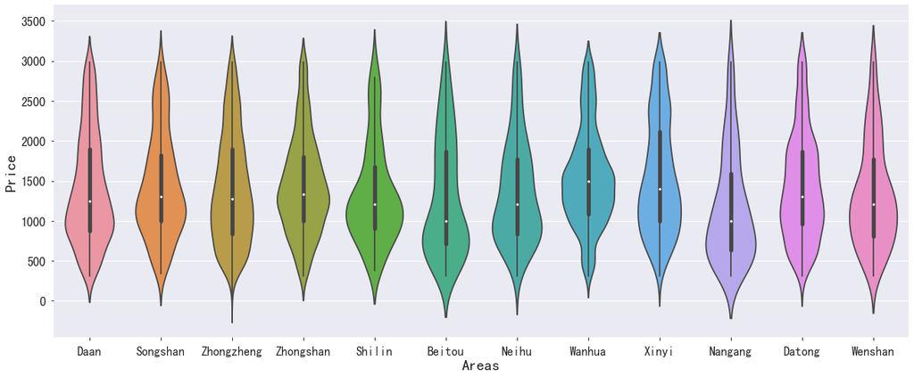

```python
df_3000=df[df['price']<3000]
plt.rcParams['font.sans-serif']=['SimHei']
plt.figure(figsize=(20,8))
sns.violinplot(data=df_3000,x='neighbourhood',y='price')
plt.xlabel('Areas',fontsize=20)
plt.ylabel('Price',fontsize=20)
plt.xticks(fontsize=16)
plt.yticks(fontsize=16)
ax = plt.gca()#取得目前座標
ax.set_xticklabels(['Daan','Songshan','Zhongzheng','Zhongshan','Shilin','Beitou','Neihu','Wanhua','Xinyi','Nangang','Datong','Wenshan'])
plt.show()
```

### ✦ Price distribution on map

```python
df_1000=df[df['price']<3000]
```

[figure not shown]

```python
import urllib
plt.figure(figsize=(10,10))
i=urllib.request.urlopen('https://images2.imgbox.com/2c/ae/mMEmrRaN_o.png')
nyc_img=plt.imread(i)
plt.figure(figsize=(10,8))
plt.imshow(nyc_img,zorder=0,extent=[121.45, 121.65, 24.95,25.175])
ax=plt.gca()
plt.figure(figsize=(10,10))
df_1000.plot(kind='scatter',x='longitude',y='latitude',c='price',cmap=plt.get_cmap('jet'),colorbar=True,alpha=0.4,ax=ax)
plt.show()
```

## Room Types

The percentage of housing is surprisingly over "a half". Usually, traveller prefers a shared room or private room for short days and tenant prefers a department or private room for long days.However, the hosts on Airbnb seem to offer more apartments than rooms. Confirm this by checking the minimum nights.

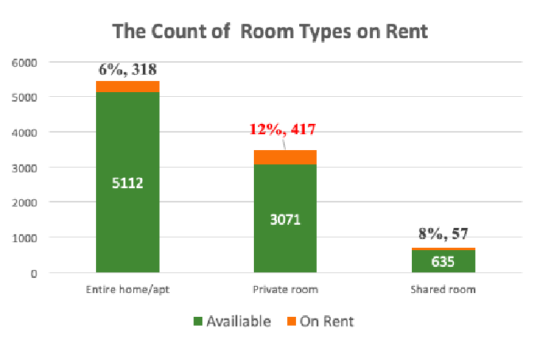

```python
plt.figure(figsize=(12,10))
roomtype=mpimg.imread('RoomType.png')
plt.imshow(roomtype)
plt.axis('off')
plt.show()
```

### ✦ The percentages of accommodation for traveller and tenant

1. There is 96% of house/room sources has a minimum night of within 2 weeks and 2 weeks is usually the limited day for travellers on a trip (depends on holidays given by the company). Only 4% of the hosts open their property to guests for long-time stay.

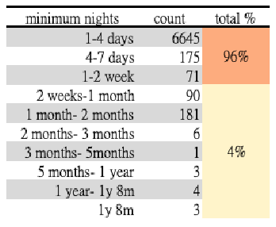

```python
plt.figure(figsize=(10,5))
mininight=mpimg.imread('mininight.png')
plt.imshow(mininight)
plt.axis('off')
plt.show()
```

### ✦An investment of travel industry？

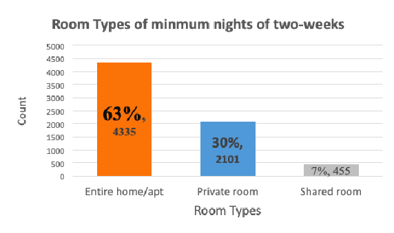

```python
plt.figure(figsize=(10,12))
mininight=mpimg.imread('mininightRoom.png')
plt.imshow(mininight)
plt.axis('off')
plt.show()
```

1. There is 16.8% of hosts post only one room or house but a huge percentage of 83.1% hosts listed over one posts on Airbnb.

```python
print(len(df[df['calculated_host_listings_count']==1])/len(df), len(df[df['calculated_host_listings_count']>1])/len(df))
```

```
0.1689644762000604 0.8310355237999396
```

```python
print('The top number of lists',df['calculated_host_listings_count'].max(),'There are',len(df[df['calculated_host_listings_count']==99]), 'hostID has 99 lists')
```

```
The top number of lists 99 There are 99 hostID has 99 lists
```

## Rooms with low minimum nights have high price?

1. The scatter chart illustrates the relationship between price and minimum nights. It doesn't have any obvious correlation

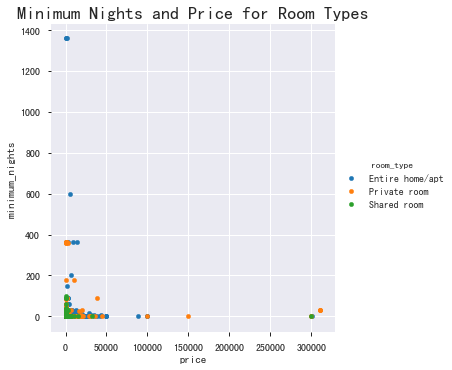

```python
plt.figure(figsize=(15,15))
sns.FacetGrid(df,hue='room_type',size=5).map(plt.scatter,'price','minimum_nights',s=20).add_legend()
plt.title('Minimum Nights and Price for Room Types', {"fontsize" : 18})
plt.ioff()
```

1. Taking room type of apartment with minimum nights of within two week and its correlation coefficient is in low correlation of -0.3 to 0.3 and near 0.

```python
day14=df[df['minimum_nights']<14]
day14[['price','room_type','minimum_nights']].groupby('room_type').corr()
```

| room_type |  | price | minimum_nights |
| --- | --- | --- | --- |
| Entire home/apt | price | 1.000000 | 0.045564 |
|  | minimum_nights | 0.045564 | 1.000000 |
| Private room | price | 1.000000 | -0.048910 |
|  | minimum_nights | -0.048910 | 1.000000 |
| Shared room | price | 1.000000 | -0.005216 |
|  | minimum_nights | -0.005216 | 1.000000 |

```python
day14more=df[(df['minimum_nights']>=14) & (df['minimum_nights']<60)]
day14more[['price','room_type','minimum_nights']].groupby('room_type').corr()
```

| room_type |  | price | minimum_nights |
| --- | --- | --- | --- |
| Entire home/apt | price | 1.000000 | -0.241488 |
|  | minimum_nights | -0.241488 | 1.000000 |
| Private room | price | 1.000000 | 0.029658 |
|  | minimum_nights | 0.029658 | 1.000000 |
| Shared room | price | 1.000000 | -0.000999 |
|  | minimum_nights | -0.000999 | 1.000000 |

# Customer Churn

✦ From the report of availability_365 has 1119 (11.3%) zeros, Airbnb may lose the source of host or the owners would temporarily close. Take a look at the data by areas, room types and prices.Lodgings are closed by guests checking in or hosts stopping using Airbnb could cause the unavailable status.

1. The number of the hosts stopping using Airbnb is **327**, and Customer Churn rate is **3.29%**

```python
df=pd.read_csv("listingsRoc.csv")
df0=df[df['availability_365']==0]
losing=df0[df0["last_review"].isnull()]
print(len(losing),len(losing)/len(df))
```

```
327 0.03290731609137567
```

Of all of 327 data, take a look at the percentages and numbers for the columns of areas, room types and nimimum nights

1. Daan(大安 23%), Zhongshan(中山 14%) and Xinyi(信義 13%) District lose the most share counting for a total of 50%, followed by Wanhua 萬華 of 10%.
2. There are 188 (58%) private rooms closing to people and 105 (32%) apartments are unavailiable.
3. The lodgings with minimum nights of 1-3 lose the largest share.

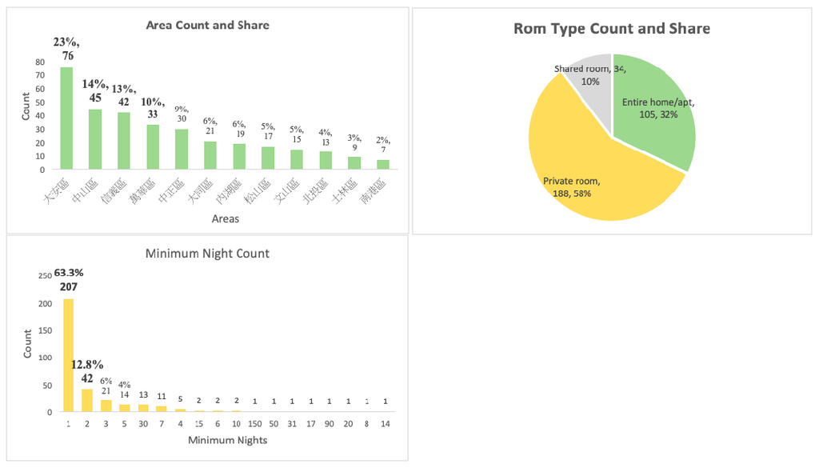

```python
plt.figure(figsize=(22,11))
countArea = mpimg.imread('losing3.png')
plt.imshow(countArea)
plt.axis('off')
plt.show()
```

# Accommodation On Rent

```python
onRent=df0[df0['last_review'].isnull().values==False]
print(len(onRent),len(onRent)/len(df))
```

```
792 0.07970212337727685
```

The profit in this month is at least around **22738346**

```python
profit=onRent['price']*onRent['minimum_nights']
profit.sum()
```

```
22738346
```

## Areas

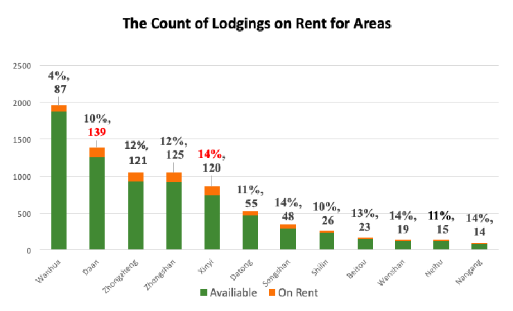

```python
plt.figure(figsize=(16,8))
noRunArea = mpimg.imread('OnRentArea.png')
plt.imshow(noRunArea)
plt.axis('off')
plt.show()
```

## Room Types

✦ For room type, private room is the most popular.

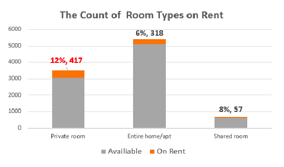

```python
plt.figure(figsize=(10,6))
noRunRoomType=mpimg.imread('onRentRoom.png')
plt.imshow(noRunRoomType)
plt.axis('off')
plt.show()
```

## Prices

✦ Of all price range, the price under 2500 is popular and most people (228) choose lodgings with the price on 500-1000

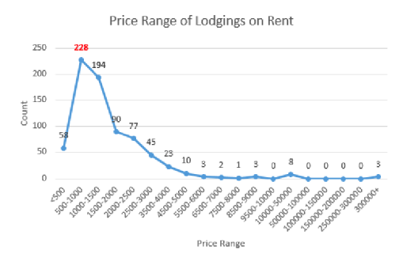

```python
plt.figure(figsize=(12,6))
noRunRoomType=mpimg.imread('OnRentPrice.png')
plt.imshow(noRunRoomType)
plt.axis('off')
plt.show()
```